# Risk Factor Analysis

## Outcome Variable

**Outcome Variable:** sstunted

## Predictor Variables

**Intervention Variable:** predfeed3

**Adjustment Set:**

- arm
- sex
- month
- brthmon
- W_mage
- meducyrs
- feducyrs
- hhwealth_quart
- hfoodsec
- W_mhtcm
- vagbrth
- W_gagebrth
- W_birthwt
- W_birthlen
- W_nrooms
- W_nchldlt5
- W_parity
- impfloor
- impsan
- safeh20
- delta_W_mage
- delta_meducyrs
- delta_feducyrs
- delta_hhwealth_quart
- delta_hfoodsec
- delta_W_mhtcm
- delta_vagbrth
- delta_W_gagebrth
- delta_W_birthwt
- delta_W_birthlen
- delta_W_nrooms
- delta_W_nchldlt5
- delta_W_parity
- delta_impfloor
- delta_impsan
- delta_safeh20

## Stratifying Variables

The analysis was stratified on these variable(s):

- agecat
- studyid
- country

## Data Summary

| agecat | studyid | country | predfeed3 | sstunted | n_cell | n |
| --- | --- | --- | --- | --- | --- | --- |
| Birth | ki0047075b-MAL-ED | BANGLADESH | 1 | 0 | 198 | 240 |
| Birth | ki0047075b-MAL-ED | BANGLADESH | 1 | 1 | 7 | 240 |
| Birth | ki0047075b-MAL-ED | BANGLADESH | 0 | 0 | 35 | 240 |
| Birth | ki0047075b-MAL-ED | BANGLADESH | 0 | 1 | 0 | 240 |
| Birth | ki0047075b-MAL-ED | BRAZIL | 1 | 0 | 97 | 185 |
| Birth | ki0047075b-MAL-ED | BRAZIL | 1 | 1 | 4 | 185 |
| Birth | ki0047075b-MAL-ED | BRAZIL | 0 | 0 | 80 | 185 |
| Birth | ki0047075b-MAL-ED | BRAZIL | 0 | 1 | 4 | 185 |
| Birth | ki0047075b-MAL-ED | INDIA | 1 | 0 | 147 | 196 |
| Birth | ki0047075b-MAL-ED | INDIA | 1 | 1 | 5 | 196 |
| Birth | ki0047075b-MAL-ED | INDIA | 0 | 0 | 42 | 196 |
| Birth | ki0047075b-MAL-ED | INDIA | 0 | 1 | 2 | 196 |
| Birth | ki0047075b-MAL-ED | NEPAL | 1 | 0 | 96 | 171 |
| Birth | ki0047075b-MAL-ED | NEPAL | 1 | 1 | 3 | 171 |
| Birth | ki0047075b-MAL-ED | NEPAL | 0 | 0 | 69 | 171 |
| Birth | ki0047075b-MAL-ED | NEPAL | 0 | 1 | 3 | 171 |
| Birth | ki0047075b-MAL-ED | PERU | 1 | 0 | 178 | 272 |
| Birth | ki0047075b-MAL-ED | PERU | 1 | 1 | 5 | 272 |
| Birth | ki0047075b-MAL-ED | PERU | 0 | 0 | 88 | 272 |
| Birth | ki0047075b-MAL-ED | PERU | 0 | 1 | 1 | 272 |
| Birth | ki0047075b-MAL-ED | SOUTH AFRICA | 1 | 0 | 87 | 233 |
| Birth | ki0047075b-MAL-ED | SOUTH AFRICA | 1 | 1 | 0 | 233 |
| Birth | ki0047075b-MAL-ED | SOUTH AFRICA | 0 | 0 | 145 | 233 |
| Birth | ki0047075b-MAL-ED | SOUTH AFRICA | 0 | 1 | 1 | 233 |
| Birth | ki0047075b-MAL-ED | TANZANIA, UNITED REPUBLIC OF | 1 | 0 | 48 | 119 |
| Birth | ki0047075b-MAL-ED | TANZANIA, UNITED REPUBLIC OF | 1 | 1 | 2 | 119 |
| Birth | ki0047075b-MAL-ED | TANZANIA, UNITED REPUBLIC OF | 0 | 0 | 65 | 119 |
| Birth | ki0047075b-MAL-ED | TANZANIA, UNITED REPUBLIC OF | 0 | 1 | 4 | 119 |
| Birth | ki1000109-EE | PAKISTAN | 1 | 0 | 2 | 2 |
| Birth | ki1000109-EE | PAKISTAN | 1 | 1 | 0 | 2 |

[output cut: 94 more lines]

The following strata were considered:

- agecat: 24 months, studyid: ki0047075b-MAL-ED, country: BANGLADESH
- agecat: 24 months, studyid: ki0047075b-MAL-ED, country: BRAZIL
- agecat: 24 months, studyid: ki0047075b-MAL-ED, country: INDIA
- agecat: 24 months, studyid: ki0047075b-MAL-ED, country: NEPAL
- agecat: 24 months, studyid: ki0047075b-MAL-ED, country: PERU
- agecat: 24 months, studyid: ki0047075b-MAL-ED, country: SOUTH AFRICA
- agecat: 24 months, studyid: ki0047075b-MAL-ED, country: TANZANIA, UNITED REPUBLIC OF
- agecat: 24 months, studyid: ki1113344-GMS-Nepal, country: NEPAL
- agecat: 24 months, studyid: kiGH5241-JiVitA-3, country: BANGLADESH
- agecat: 24 months, studyid: kiGH5241-JiVitA-4, country: BANGLADESH
- agecat: 6 months, studyid: ki0047075b-MAL-ED, country: BANGLADESH
- agecat: 6 months, studyid: ki0047075b-MAL-ED, country: BRAZIL
- agecat: 6 months, studyid: ki0047075b-MAL-ED, country: INDIA
- agecat: 6 months, studyid: ki0047075b-MAL-ED, country: NEPAL
- agecat: 6 months, studyid: ki0047075b-MAL-ED, country: PERU
- agecat: 6 months, studyid: ki0047075b-MAL-ED, country: SOUTH AFRICA
- agecat: 6 months, studyid: ki0047075b-MAL-ED, country: TANZANIA, UNITED REPUBLIC OF
- agecat: 6 months, studyid: ki1000109-EE, country: PAKISTAN
- agecat: 6 months, studyid: ki1113344-GMS-Nepal, country: NEPAL
- agecat: 6 months, studyid: kiGH5241-JiVitA-3, country: BANGLADESH
- agecat: 6 months, studyid: kiGH5241-JiVitA-4, country: BANGLADESH
- agecat: Birth, studyid: ki0047075b-MAL-ED, country: BANGLADESH
- agecat: Birth, studyid: ki0047075b-MAL-ED, country: BRAZIL
- agecat: Birth, studyid: ki0047075b-MAL-ED, country: INDIA
- agecat: Birth, studyid: ki0047075b-MAL-ED, country: NEPAL
- agecat: Birth, studyid: ki0047075b-MAL-ED, country: PERU
- agecat: Birth, studyid: ki0047075b-MAL-ED, country: SOUTH AFRICA
- agecat: Birth, studyid: ki0047075b-MAL-ED, country: TANZANIA, UNITED REPUBLIC OF
- agecat: Birth, studyid: ki1000109-EE, country: PAKISTAN
- agecat: Birth, studyid: kiGH5241-JiVitA-3, country: BANGLADESH
- agecat: Birth, studyid: kiGH5241-JiVitA-4, country: BANGLADESH

### Dropped Strata

Some strata were dropped due to rare outcomes:

- agecat: Birth, studyid: ki0047075b-MAL-ED, country: BANGLADESH
- agecat: Birth, studyid: ki0047075b-MAL-ED, country: BRAZIL
- agecat: Birth, studyid: ki0047075b-MAL-ED, country: INDIA
- agecat: Birth, studyid: ki0047075b-MAL-ED, country: NEPAL
- agecat: Birth, studyid: ki0047075b-MAL-ED, country: PERU
- agecat: Birth, studyid: ki0047075b-MAL-ED, country: SOUTH AFRICA
- agecat: Birth, studyid: ki0047075b-MAL-ED, country: TANZANIA, UNITED REPUBLIC OF
- agecat: Birth, studyid: ki1000109-EE, country: PAKISTAN
- agecat: Birth, studyid: kiGH5241-JiVitA-4, country: BANGLADESH
- agecat: 6 months, studyid: ki0047075b-MAL-ED, country: BANGLADESH
- agecat: 6 months, studyid: ki0047075b-MAL-ED, country: BRAZIL
- agecat: 6 months, studyid: ki0047075b-MAL-ED, country: INDIA
- agecat: 6 months, studyid: ki0047075b-MAL-ED, country: NEPAL
- agecat: 6 months, studyid: ki0047075b-MAL-ED, country: PERU
- agecat: 6 months, studyid: ki0047075b-MAL-ED, country: SOUTH AFRICA
- agecat: 6 months, studyid: kiGH5241-JiVitA-4, country: BANGLADESH
- agecat: 24 months, studyid: ki0047075b-MAL-ED, country: BANGLADESH
- agecat: 24 months, studyid: ki0047075b-MAL-ED, country: BRAZIL
- agecat: 24 months, studyid: ki0047075b-MAL-ED, country: NEPAL
- agecat: 24 months, studyid: ki0047075b-MAL-ED, country: PERU
- agecat: 24 months, studyid: kiGH5241-JiVitA-4, country: BANGLADESH

## Methods Detail

We’re interested in the causal parameters $E[Y_a]$ for all values of $a \in \mathcal{A}$. These parameters represent the mean outcome if, possibly contrary to fact, we intervened to set all units to have $A=a$. Under the randomization and positivity assumptions, these are identified by the statistical parameters $\psi_a=E_W[E_{Y|A,W}(Y|A=a,W)]$. In addition, we’re interested in the mean of $Y$, $E[Y]$ under no intervention (the observed mean). We will estimate these parameters by using SuperLearner to fit the relevant likelihood factors – $E_{Y|A,W}(Y|A=a,W)$ and $p(A=a|W)$, and then updating our likelihood fit using a joint TMLE.

For unadjusted analyses ($W=\{\}$), initial likelihoods were estimated using Lrnr_glm to estimate the simple $E(Y|A)$ and Lrnr_mean to estimate $p(A)$. For adjusted analyses, a small library containing Lrnr_glmnet, Lrnr_xgboost, and Lrnr_mean was used.

Having estimated these parameters, we will then use the delta method to estimate relative risks and attributable risks relative to a prespecified baseline level of $A$.

# Results Detail

## Results Plots

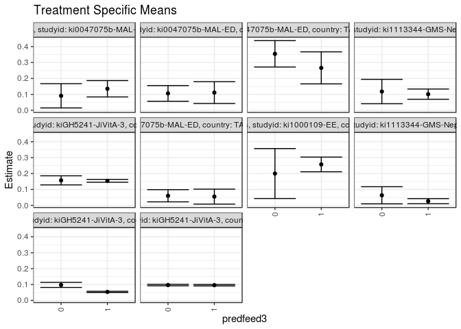

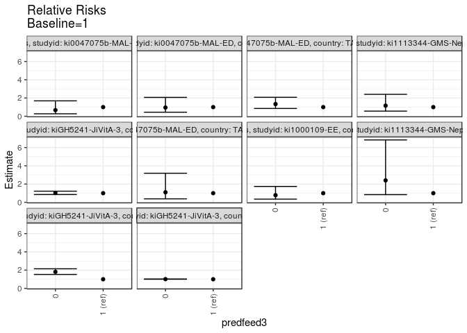

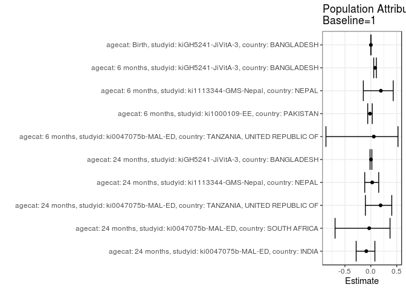

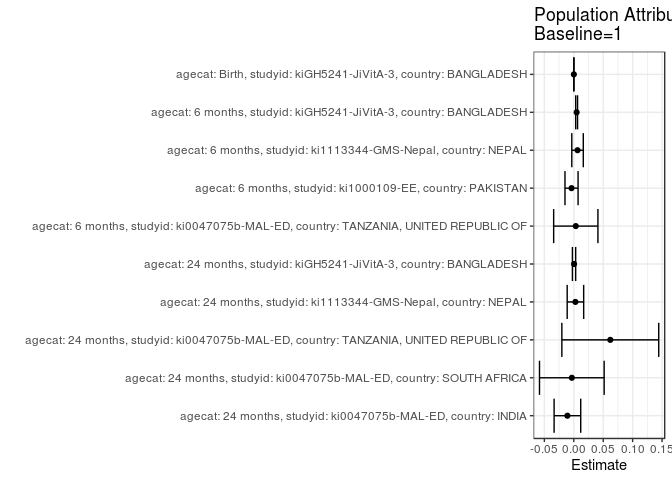

## Results Table

### Parameter: TSM

| agecat | studyid | country | intervention_level | baseline_level | estimate | ci_lower | ci_upper |
| --- | --- | --- | --- | --- | --- | --- | --- |
| Birth | kiGH5241-JiVitA-3 | BANGLADESH | 1 | NA | 0.0958769 | 0.0913122 | 0.1004417 |
| Birth | kiGH5241-JiVitA-3 | BANGLADESH | 0 | NA | 0.0968253 | 0.0921315 | 0.1015190 |
| 6 months | ki0047075b-MAL-ED | TANZANIA, UNITED REPUBLIC OF | 1 | NA | 0.0549451 | 0.0080284 | 0.1018617 |
| 6 months | ki0047075b-MAL-ED | TANZANIA, UNITED REPUBLIC OF | 0 | NA | 0.0604027 | 0.0220708 | 0.0987346 |
| 6 months | ki1000109-EE | PAKISTAN | 1 | NA | 0.2572254 | 0.2111063 | 0.3033446 |
| 6 months | ki1000109-EE | PAKISTAN | 0 | NA | 0.2000000 | 0.0429911 | 0.3570089 |
| 6 months | ki1113344-GMS-Nepal | NEPAL | 1 | NA | 0.0263852 | 0.0102313 | 0.0425391 |
| 6 months | ki1113344-GMS-Nepal | NEPAL | 0 | NA | 0.0632911 | 0.0095406 | 0.1170417 |
| 6 months | kiGH5241-JiVitA-3 | BANGLADESH | 1 | NA | 0.0538941 | 0.0502550 | 0.0575332 |
| 6 months | kiGH5241-JiVitA-3 | BANGLADESH | 0 | NA | 0.0974941 | 0.0813733 | 0.1136150 |
| 24 months | ki0047075b-MAL-ED | INDIA | 1 | NA | 0.1352941 | 0.0837636 | 0.1868246 |
| 24 months | ki0047075b-MAL-ED | INDIA | 0 | NA | 0.0909091 | 0.0147641 | 0.1670541 |
| 24 months | ki0047075b-MAL-ED | SOUTH AFRICA | 1 | NA | 0.1111111 | 0.0425234 | 0.1796988 |
| 24 months | ki0047075b-MAL-ED | SOUTH AFRICA | 0 | NA | 0.1059603 | 0.0567623 | 0.1551583 |
| 24 months | ki0047075b-MAL-ED | TANZANIA, UNITED REPUBLIC OF | 1 | NA | 0.2665479 | 0.1658576 | 0.3672381 |
| 24 months | ki0047075b-MAL-ED | TANZANIA, UNITED REPUBLIC OF | 0 | NA | 0.3547365 | 0.2718555 | 0.4376174 |
| 24 months | ki1113344-GMS-Nepal | NEPAL | 1 | NA | 0.1011905 | 0.0689040 | 0.1334769 |
| 24 months | ki1113344-GMS-Nepal | NEPAL | 0 | NA | 0.1176471 | 0.0409739 | 0.1943202 |
| 24 months | kiGH5241-JiVitA-3 | BANGLADESH | 1 | NA | 0.1542287 | 0.1451604 | 0.1632970 |
| 24 months | kiGH5241-JiVitA-3 | BANGLADESH | 0 | NA | 0.1571480 | 0.1286426 | 0.1856534 |

### Parameter: E(Y)

| agecat | studyid | country | intervention_level | baseline_level | estimate | ci_lower | ci_upper |
| --- | --- | --- | --- | --- | --- | --- | --- |
| Birth | kiGH5241-JiVitA-3 | BANGLADESH | NA | NA | 0.0959914 | 0.0914158 | 0.1005671 |
| 6 months | ki0047075b-MAL-ED | TANZANIA, UNITED REPUBLIC OF | NA | NA | 0.0583333 | 0.0286197 | 0.0880470 |
| 6 months | ki1000109-EE | PAKISTAN | NA | NA | 0.2533693 | 0.2090516 | 0.2976870 |
| 6 months | ki1113344-GMS-Nepal | NEPAL | NA | NA | 0.0327511 | 0.0164329 | 0.0490693 |
| 6 months | kiGH5241-JiVitA-3 | BANGLADESH | NA | NA | 0.0587188 | 0.0549206 | 0.0625169 |
| 24 months | ki0047075b-MAL-ED | INDIA | NA | NA | 0.1244444 | 0.0812176 | 0.1676713 |
| 24 months | ki0047075b-MAL-ED | SOUTH AFRICA | NA | NA | 0.1077586 | 0.0677725 | 0.1477447 |
| 24 months | ki0047075b-MAL-ED | TANZANIA, UNITED REPUBLIC OF | NA | NA | 0.3285714 | 0.2648934 | 0.3922495 |
| 24 months | ki1113344-GMS-Nepal | NEPAL | NA | NA | 0.1039604 | 0.0741620 | 0.1337588 |
| 24 months | kiGH5241-JiVitA-3 | BANGLADESH | NA | NA | 0.1546577 | 0.1455620 | 0.1637534 |

### Parameter: RR

| agecat | studyid | country | intervention_level | baseline_level | estimate | ci_lower | ci_upper |
| --- | --- | --- | --- | --- | --- | --- | --- |
| Birth | kiGH5241-JiVitA-3 | BANGLADESH | 1 | 1 | 1.0000000 | 1.0000000 | 1.000000 |
| Birth | kiGH5241-JiVitA-3 | BANGLADESH | 0 | 1 | 1.0098910 | 1.0015921 | 1.018259 |
| 6 months | ki0047075b-MAL-ED | TANZANIA, UNITED REPUBLIC OF | 1 | 1 | 1.0000000 | 1.0000000 | 1.000000 |
| 6 months | ki0047075b-MAL-ED | TANZANIA, UNITED REPUBLIC OF | 0 | 1 | 1.0993289 | 0.3793939 | 3.185407 |
| 6 months | ki1000109-EE | PAKISTAN | 1 | 1 | 1.0000000 | 1.0000000 | 1.000000 |
| 6 months | ki1000109-EE | PAKISTAN | 0 | 1 | 0.7775281 | 0.3475336 | 1.739544 |
| 6 months | ki1113344-GMS-Nepal | NEPAL | 1 | 1 | 1.0000000 | 1.0000000 | 1.000000 |
| 6 months | ki1113344-GMS-Nepal | NEPAL | 0 | 1 | 2.3987342 | 0.8419859 | 6.833755 |
| 6 months | kiGH5241-JiVitA-3 | BANGLADESH | 1 | 1 | 1.0000000 | 1.0000000 | 1.000000 |
| 6 months | kiGH5241-JiVitA-3 | BANGLADESH | 0 | 1 | 1.8089948 | 1.5247881 | 2.146175 |
| 24 months | ki0047075b-MAL-ED | INDIA | 1 | 1 | 1.0000000 | 1.0000000 | 1.000000 |
| 24 months | ki0047075b-MAL-ED | INDIA | 0 | 1 | 0.6719368 | 0.2677457 | 1.686298 |
| 24 months | ki0047075b-MAL-ED | SOUTH AFRICA | 1 | 1 | 1.0000000 | 1.0000000 | 1.000000 |
| 24 months | ki0047075b-MAL-ED | SOUTH AFRICA | 0 | 1 | 0.9536424 | 0.4404835 | 2.064626 |
| 24 months | ki0047075b-MAL-ED | TANZANIA, UNITED REPUBLIC OF | 1 | 1 | 1.0000000 | 1.0000000 | 1.000000 |
| 24 months | ki0047075b-MAL-ED | TANZANIA, UNITED REPUBLIC OF | 0 | 1 | 1.3308547 | 0.8523237 | 2.078054 |
| 24 months | ki1113344-GMS-Nepal | NEPAL | 1 | 1 | 1.0000000 | 1.0000000 | 1.000000 |
| 24 months | ki1113344-GMS-Nepal | NEPAL | 0 | 1 | 1.1626297 | 0.5627332 | 2.402040 |
| 24 months | kiGH5241-JiVitA-3 | BANGLADESH | 1 | 1 | 1.0000000 | 1.0000000 | 1.000000 |
| 24 months | kiGH5241-JiVitA-3 | BANGLADESH | 0 | 1 | 1.0189283 | 0.8520530 | 1.218486 |

### Parameter: PAR

| agecat | studyid | country | intervention_level | baseline_level | estimate | ci_lower | ci_upper |
| --- | --- | --- | --- | --- | --- | --- | --- |
| Birth | kiGH5241-JiVitA-3 | BANGLADESH | 1 | NA | 0.0001145 | 0.0000032 | 0.0002258 |
| 6 months | ki0047075b-MAL-ED | TANZANIA, UNITED REPUBLIC OF | 1 | NA | 0.0033883 | -0.0342262 | 0.0410028 |
| 6 months | ki1000109-EE | PAKISTAN | 1 | NA | -0.0038562 | -0.0149797 | 0.0072674 |
| 6 months | ki1113344-GMS-Nepal | NEPAL | 1 | NA | 0.0063659 | -0.0033992 | 0.0161309 |
| 6 months | kiGH5241-JiVitA-3 | BANGLADESH | 1 | NA | 0.0048247 | 0.0032551 | 0.0063942 |
| 24 months | ki0047075b-MAL-ED | INDIA | 1 | NA | -0.0108497 | -0.0334629 | 0.0117636 |
| 24 months | ki0047075b-MAL-ED | SOUTH AFRICA | 1 | NA | -0.0033525 | -0.0582914 | 0.0515864 |
| 24 months | ki0047075b-MAL-ED | TANZANIA, UNITED REPUBLIC OF | 1 | NA | 0.0620236 | -0.0202954 | 0.1443426 |
| 24 months | ki1113344-GMS-Nepal | NEPAL | 1 | NA | 0.0027699 | -0.0112459 | 0.0167857 |
| 24 months | kiGH5241-JiVitA-3 | BANGLADESH | 1 | NA | 0.0004290 | -0.0023307 | 0.0031887 |

### Parameter: PAF

| agecat | studyid | country | intervention_level | baseline_level | estimate | ci_lower | ci_upper |
| --- | --- | --- | --- | --- | --- | --- | --- |
| Birth | kiGH5241-JiVitA-3 | BANGLADESH | 1 | NA | 0.0011930 | 0.0000376 | 0.0023470 |
| 6 months | ki0047075b-MAL-ED | TANZANIA, UNITED REPUBLIC OF | 1 | NA | 0.0580848 | -0.8665787 | 0.5246896 |
| 6 months | ki1000109-EE | PAKISTAN | 1 | NA | -0.0152195 | -0.0600590 | 0.0277233 |
| 6 months | ki1113344-GMS-Nepal | NEPAL | 1 | NA | 0.1943712 | -0.1445616 | 0.4329376 |
| 6 months | kiGH5241-JiVitA-3 | BANGLADESH | 1 | NA | 0.0821655 | 0.0561957 | 0.1074207 |
| 24 months | ki0047075b-MAL-ED | INDIA | 1 | NA | -0.0871849 | -0.2828980 | 0.0786711 |
| 24 months | ki0047075b-MAL-ED | SOUTH AFRICA | 1 | NA | -0.0311111 | -0.6904449 | 0.3710590 |
| 24 months | ki0047075b-MAL-ED | TANZANIA, UNITED REPUBLIC OF | 1 | NA | 0.1887674 | -0.1051109 | 0.4044957 |
| 24 months | ki1113344-GMS-Nepal | NEPAL | 1 | NA | 0.0266440 | -0.1177654 | 0.1523965 |
| 24 months | kiGH5241-JiVitA-3 | BANGLADESH | 1 | NA | 0.0027738 | -0.0152048 | 0.0204340 |